# 2017-10-18-the-whole-elephant

2017-11-02 08:15:42

[figure not shown]

## Support

[figure not shown]

## Talk overview

- Project status report
  - The development of optic flow processing
  - *P*lay & *L*earning *A*cross a *Year* (PLAY) project
  - The *P*roximal *E*motional *E*nvironment *P*roject (PEEP)
- Toward an open, transparent, robust, and integrative developmental science

## The development of optic flow processing

## Questions about optic flow

- What is optic flow?
- Why is optic flow important?
- How does optic flow sensitivity develop?
- How do brain systems for processing optic flow develop?
- What shapes these patterns of development?

## Approach

- **EEG measures** of brain responses to optic flow
- **Psychophysical (behavioral) measures** of optic flow perception
- **Empirical measures** of experienced optic flow across development from head-mounted video cameras and **computer vision** analyses

## What is Optic Flow?

- Structured pattern of visual motion generated by observer movement

[video not shown]

## Types of Optic Flow

[figure not shown]

[(Yu, Page, Gaborski, & Duffy, 2010)](http://doi.org/10.1152/jn.01085.2009)

[figure not shown]

## Why is optic flow important?

- Geometry of environment
  - Surface layout, orientation
  - Object motion
- Visual proprioception
  - Rotation, translation

## Flow types specify self-motion

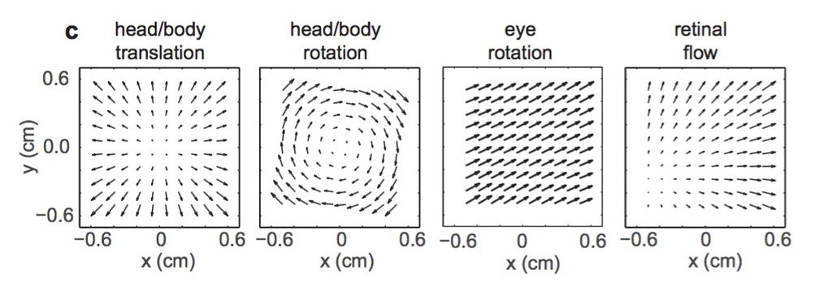

## How Does Optic Flow Sensitivity Develop?

- Sensitivity at birth, (Jouen, Lepecq, Gapenne, & Bertenthal, 2000)
- 4-6 mo-old infants: Larger brain responses to **linear** patterns, [(R. Gilmore, Hou, Pettet, & Norcia, 2007)](http://doi.org/10.1017/S0952523807070769)

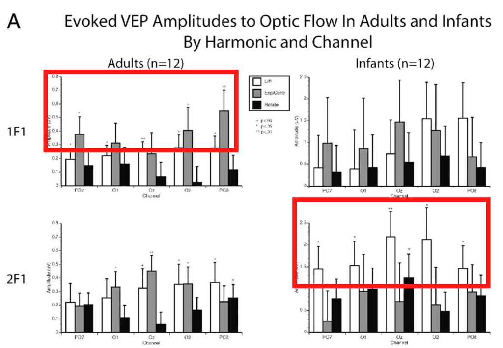

## How Does Optic Flow Sensitivity Develop?

- 4-6 mo-old infants: Larger brain responses to **faster** speeds/larger displacements, [(Hou, Gilmore, Pettet, & Norcia, 2009)](http://doi.org/10.1016/j.visres.2009.08.007)

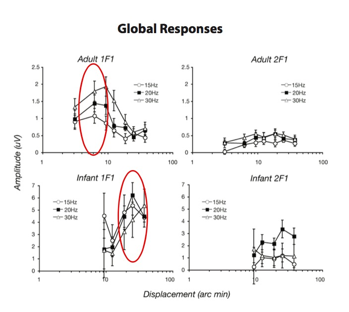

## How Does Optic Flow Sensitivity Develop?

- Behavioral sensitivity to slow (linear) speeds develops slowly in macaque monkeys, [(Kiorpes & Movshon, 2004)](http://doi.org/10.1017/S0952523804216054)

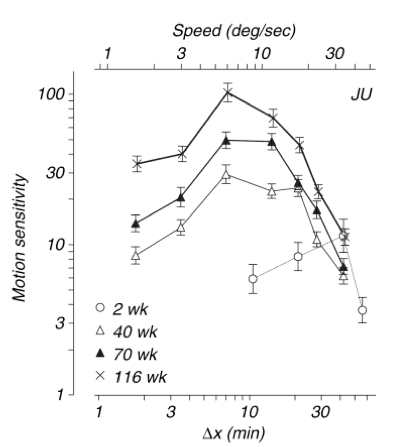

## What about older children?

- Present: Time-varying optic flow patterns
- Measure: Steady-state visual evoked potentials (SSVEPs)
  - Event-related electro-encephalograms (EEGs)
  - Phase-locked responses at low-order harmonics
- \(n=29\) 4-8 year-olds
- [(R. Gilmore, Thomas, & Fesi, 2016)](http://doi.org/10.1371/journal.pone.0157911)

## 2 deg/s translation

[video not shown]

https://nyu.databrary.org/volume/75/slot/9825/-

## 4 deg/s rotation

[video not shown]

https://nyu.databrary.org/volume/75/slot/9825/-

## 8 deg/s radial

[video not shown]

https://nyu.databrary.org/volume/75/slot/9825/-

## [1F1 Channel-Wise Results](https://raw.githubusercontent.com/gilmore-lab/gilmore-thomas-fesi-2015/master/figs/1F1/child/figX-channel-wise-effects-1.png)

[figure not shown]

[(R. Gilmore et al., 2016)](http://doi.org/10.1371/journal.pone.0157911)

## [1F1 Channels *p* < .0005](https://raw.githubusercontent.com/gilmore-lab/gilmore-thomas-fesi-2015/master/figs/1F1/child/figX-vector-amplitude-barplots-pattern-1.png)

[figure not shown]

[(R. Gilmore et al., 2016)](http://doi.org/10.1371/journal.pone.0157911)

## [Complex Domain Plot of 1F1 Channels](https://raw.githubusercontent.com/gilmore-lab/gilmore-thomas-fesi-2015/master/figs/1F1/child/figX-complex-domain-plots-pattern-1.png)

[figure not shown]

[(R. Gilmore et al., 2016)](http://doi.org/10.1371/journal.pone.0157911)

## [3F1 Channel-Wise Results](https://rawgit.com/gilmore-lab/gilmore-thomas-fesi-2015/master/figs/3F1/child/channel-wise-effects-1.png)

[figure not shown]

[(R. Gilmore et al., 2016)](http://doi.org/10.1371/journal.pone.0157911)

## [3F1 Channels *p* < .0005](https://raw.githubusercontent.com/gilmore-lab/gilmore-thomas-fesi-2015/master/figs/3F1/child/figX-vector-amplitude-barplots-speed-1.png)

[figure not shown]

[(R. Gilmore et al., 2016)](http://doi.org/10.1371/journal.pone.0157911)

## [Complex Domain Plot of 3F1 Channels](https://rawgit.com/gilmore-lab/gilmore-thomas-fesi-2015/master/figs/3F1/child/figX-complex-domain-plots-speed-1.png)

[figure not shown]

[(R. Gilmore et al., 2016)](http://doi.org/10.1371/journal.pone.0157911)

## Results Summary

- Anatomical & frequency separation of responses
  - vs. pattern (lateral, 1F1)
  - speed (medial, 3F1)
- Radial & rotation \(\neq\) translation
- Speed tuning (slow < med & fast)
- Similar to, but different from adults

## [Children's 1F1](https://raw.githubusercontent.com/gilmore-lab/gilmore-thomas-fesi-2015/master/figs/1F1/child/figX-channel-wise-effects-1.png)

[figure not shown]

[(R. Gilmore et al., 2016)](http://doi.org/10.1371/journal.pone.0157911)

## [Adults' 1F1](https://raw.githubusercontent.com/gilmore-lab/gilmore-thomas-fesi-2015/master/figs/1F1/adult/figX-channel-wise-effects-1.png)

[figure not shown]

[(R. Gilmore et al., 2016)](http://doi.org/10.1371/journal.pone.0157911)

## [Children's 3F1](https://raw.githubusercontent.com/gilmore-lab/gilmore-thomas-fesi-2015/master/figs/3F1/child/figX-channel-wise-effects-1.png)

[figure not shown]

[(R. Gilmore et al., 2016)](http://doi.org/10.1371/journal.pone.0157911)

## [Adults' 3F1](https://raw.githubusercontent.com/gilmore-lab/gilmore-thomas-fesi-2015/master/figs/3F1/adult/figX-channel-wise-effects-1.png)

[figure not shown]

[(R. Gilmore et al., 2016)](http://doi.org/10.1371/journal.pone.0157911)

## What about behavior?

- Time-varying optic flow
  - Radial, linear
  - {2 deg/s, 8 deg/s}
  - {5, 10, 15, 20%} coherence (adults)
  - {15, 30, 45, 60%} and {20, 40, 60, 80%} (children)

[figure not shown]

## Methods

- n=30 children (4.3–8.6 yrs, M = 6.5 yrs, 19 Female)
  - https://nyu.databrary.org/volume/218
- n=30 adults (18.7–23.9 yrs, M = 20.8 yrs, 16 female)
  - http://doi.org/10.17910/B7V88T
  - [(Adamiak, Thomas, Patel, & Gilmore, 2015)](http://doi.org/10.1167/15.12.1008)

## Children's responses *p*(correct)

[figure not shown]

## Adults' responses *p*(correct)

[figure not shown]

[(Adamiak et al., 2015)](http://doi.org/10.1167/15.12.1008)

## Speed effects in children

[figure not shown]

## Speed effects in adults

[figure not shown]

[(Adamiak et al., 2015)](http://doi.org/10.1167/15.12.1008)

## Pattern effects in children

[figure not shown]

## Pattern effects in adults

[figure not shown]

[(Adamiak et al., 2015)](http://doi.org/10.1167/15.12.1008)

## Potential factors shaping development of flow sensitivity

- External
  - Environment
- Internal
  - Posture
  - Locomotion, head, eye movements

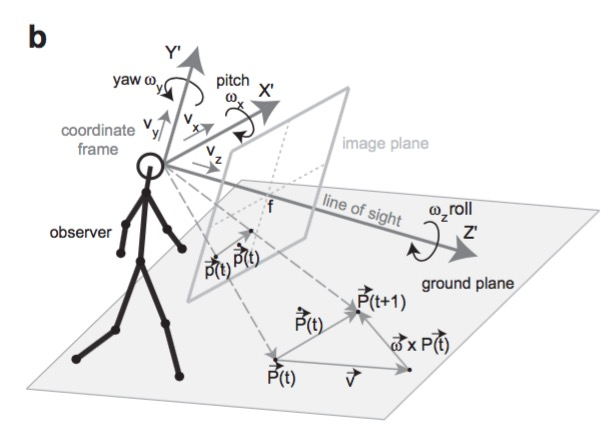

## Head mounted eye tracker data from "coupled" infant/mom dyads

[figure not shown]

Adolph, K. (2015). Active vision in passive locomotion: real-world free viewing in infants and adults. Databrary. Retrieved February 18, 2017 from http://doi.org/10.17910/B7.123

## Synchronized infant and mother cams

[video not shown]

https://nyu.databrary.org/volume/123/slot/8238/-

[video not shown]

## Findings

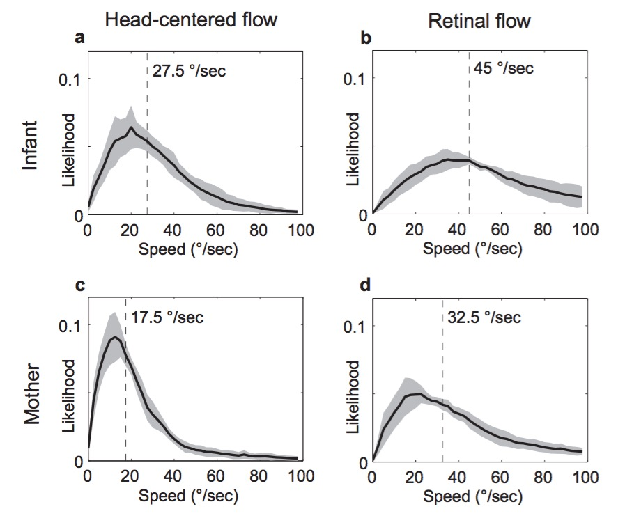

[(Raudies & Gilmore, 2014)](http://doi.org/10.1162/NECO_a_00645)

## Findings

- Infant (passengers) experience **faster motion speeds** than mothers
- Controlling for speed of locomotion, environment

[figure not shown]

## Replication

- Do the findings hold in larger samples
- When geometry of environment varies
- Outside the lab
- Across age

## Experienced flow across cultures

[video not shown]

Jayaraman, S., Smith, L.B., Raudies, F. & Gilmore, R.O. (2014). Natural Scene Statistics of Visual Experience Across Development and Culture. Databrary. Retrieved February 18, 2017 from http://doi.org/10.17910/B7988V

(R. O. Gilmore, Raudies, & Jayaraman, 2015)

[figure not shown]

[figure not shown]

## Participant summary

| Country | Females | Males | Age (wks) | Coded video Hrs |
| --- | --- | --- | --- | --- |
| India | 17 | 13 | 3-63 | 3.1 (0.5-6.0) |
| U.S. | 15 | 19 | 4-62 | 4.6 (0.2-7.6) |

(R. O. Gilmore et al., 2015)

## Illustrative Speed Histograms - 6 weeks

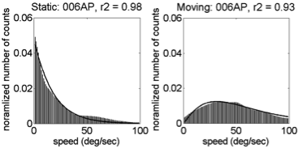

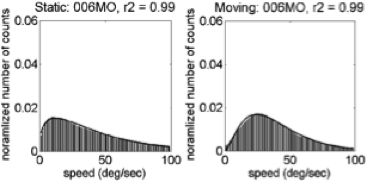

(R. O. Gilmore et al., 2015)

## Illustrative Speed Histograms – 34 weeks

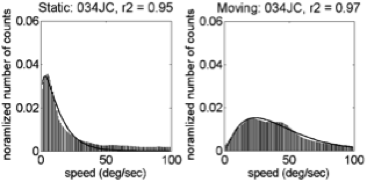

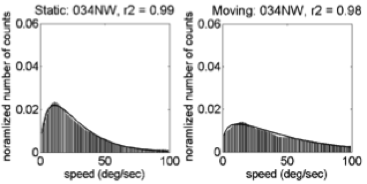

(R. O. Gilmore et al., 2015)

## Illustrative Speed Histograms – 58 weeks

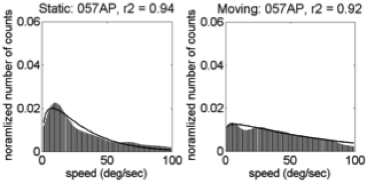

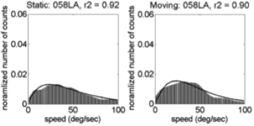

(R. O. Gilmore et al., 2015)

## Pattern Correlation Results

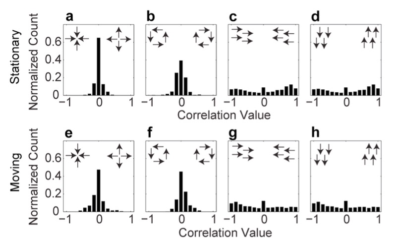

(R. O. Gilmore et al., 2015)

## Conclusions: Measuring experienced flow

- Fast speeds, broad speed distributions
- Linear flow >> radial or rotational flow

## Simulating developmental change

\(\begin{pmatrix}\dot{x} \\ \dot{y}\end{pmatrix}=\frac{1}{z} \begin{pmatrix}-f & 0 & x\\ 0 & -f & y \end{pmatrix} \begin{pmatrix}{v_x{}}\\ {v_y{}} \\{v_z{}}\end{pmatrix}+ \frac{1}{f} \begin{pmatrix} xy & -(f^2+x^2) & fy\\ f^2+y^2 & -xy & -fy \end{pmatrix} \begin{pmatrix} \omega_{x}\\ \omega_{y}\\ \omega_{z} \end{pmatrix}\)

**Geometry of environment/observer**: \((x, y, z)\)  
**Translational speed**: \((v_x, v_y, v_z)\)  
**Rotational speed**: \((\omega_{x}, \omega_{y}, \omega{z})\)  
**Retinal flow**: \((\dot{x}, \dot{y})\)

## Parameters For Simulation

| Parameter | Crawling Infant | Walking Infant |
| --- | --- | --- |
| Eye height | 0.30 m | 0.60 m |
| Locomotor speed | 0.33 m/s | 0.61 m/s |
| Head tilt | 20 deg | 9 deg |

[figure not shown]

([Kretch et al., 2014](http://dx.doi.org/10.1111/cdev.12206))

| Geometric Feature | Distance |
| --- | --- |
| Side wall | +/- 2 m |
| Side wall height | 2.5 m |
| Distance of ground plane | 32 m |
| Field of view width | 60 deg |
| Field of view height | 45 deg |

## Simulating Flow Fields

[figure not shown]

([Gilmore et al, 2015](http://doi.org/10.1109/DEVLRN.2015.7345450))

[figure not shown]

([Gilmore et al, 2015](http://doi.org/10.1109/DEVLRN.2015.7345450))

## Simulated Flow Speeds (m/s)

| Type of Locomotion | Ground Plane | Room | Side Wall | Two Walls |
| --- | --- | --- | --- | --- |
| Crawling | 14.41 | 14.42 | 14.43 | 14.62 |
| Walking | 9.38 | 8.56 | 7.39 | 9.18 |

## Some next steps

- Individual differences in flow sensitivity
- Brain responses to flow 'in the wild'
- Comparing brain responses to behavioral sensitivity
- Simulating the effects of development on visual experience
- Automating pipelines for automated analysis of 1st person videos (using PSU's Galaxy environment)

## An hour in the life…

## *P*lay & *L*earning *A*cross a *Year* project

- Play is the central context and activity of early development
- But what do parents and infants *actually do* when they 'play'?

[video not shown]

## *P*lay & *L*earning *A*cross a *Year* (PLAY) project

- \(n=900\) infant/mother dyads; 300 @ 12-, 18-, 24-months
- 30 dyads from 30 sites across the US
- 1 hr natural activity
  - 3 min solitary toy play
  - 2 min dyadic toy play
  - video tour of home

## *P*lay & *L*earning *A*cross a *Year* (PLAY) project

- Videos coded for
  - [Emotional expression](https://dev1.ed-projects.nyu.edu/wikis/docuwiki/doku.php/emotion)
  - [Object interaction](https://dev1.ed-projects.nyu.edu/wikis/docuwiki/doku.php/manual3)
  - Physical activity & [locomotion](https://dev1.ed-projects.nyu.edu/wikis/docuwiki/doku.php/manual4)
  - [Transcript](https://dev1.ed-projects.nyu.edu/wikis/docuwiki/doku.php/transcription), [Communication](https://dev1.ed-projects.nyu.edu/wikis/docuwiki/doku.php/manual2), and [Gesture](https://dev1.ed-projects.nyu.edu/wikis/docuwiki/doku.php/gesture)
- Enhancements to [Datavyu](http://datavyu.org) for transcription, CHAT compatibility, Windows support

[figure not shown]

## *P*lay & *L*earning *A*cross a *Year* (PLAY) project

- Demographics + parent-report questionnaires about health, family, temperament
- Ambient sound levels

[figure not shown]

## *P*lay & *L*earning *A*cross a *Year* (PLAY) project

- Census block group geocoding

[figure not shown]

## *P*lay & *L*earning *A*cross a *Year* (PLAY) project

- "Big data" developmental science

[figure not shown]

## *P*lay & *L*earning *A*cross a *Year* (PLAY) project

- Data shared on Databrary

[figure not shown]

## *P*lay & *L*earning *A*cross a *Year* (PLAY) project

- Video as data and documentation

[figure not shown]

[(Rick O Gilmore & Adolph, 2017)](http://doi.org/10.1038/s41562-017-0128)

[figure not shown]

## What questions would *you* ask about these data?

## The *P*roximal *E*motional *E*nvironment *P*roject (PEEP)

## Guess the emotion

| Sample 1 | Sample 2 |
| --- | --- |

## Questions

- How do children's brains respond to overheard speech with different affective prosodies?
- How do children's brains respond to different speakers?
- How do children perceive the affective qualities of overheard speech?
- What are the acoustic properties that distinguish affectively-laden speech?
- What is the natural "affective" environment

## How 'angry' are the scenarios

[figure not shown]

## How 'happy' are they?

[figure not shown]

## 'Intensity' ratings across time

[figure not shown]

## What's in common?

## Themes

- Natural environments are rich
- Perception, action, cognition & emotion inextricably linked
- Need better/denser measures
  - of environment
  - of behavior
  - of physiology

## Turtles networks all the way down…

[figure not shown]

## Power of

- convergent evidence
- data visualization
- data, materials sharing
- to accelerate discovery…

## Limitations of

- scientific culture
- technology
- sampling diversity, sample sizes/power, publication bias, etc.
- big team science vs. small team science

## Toward an open, transparent, robust, and integrative developmental science

[figure not shown]

## What would a data observatory for human development look like?

## Combine data from diverse domains

[figure not shown]

## Link measures across people

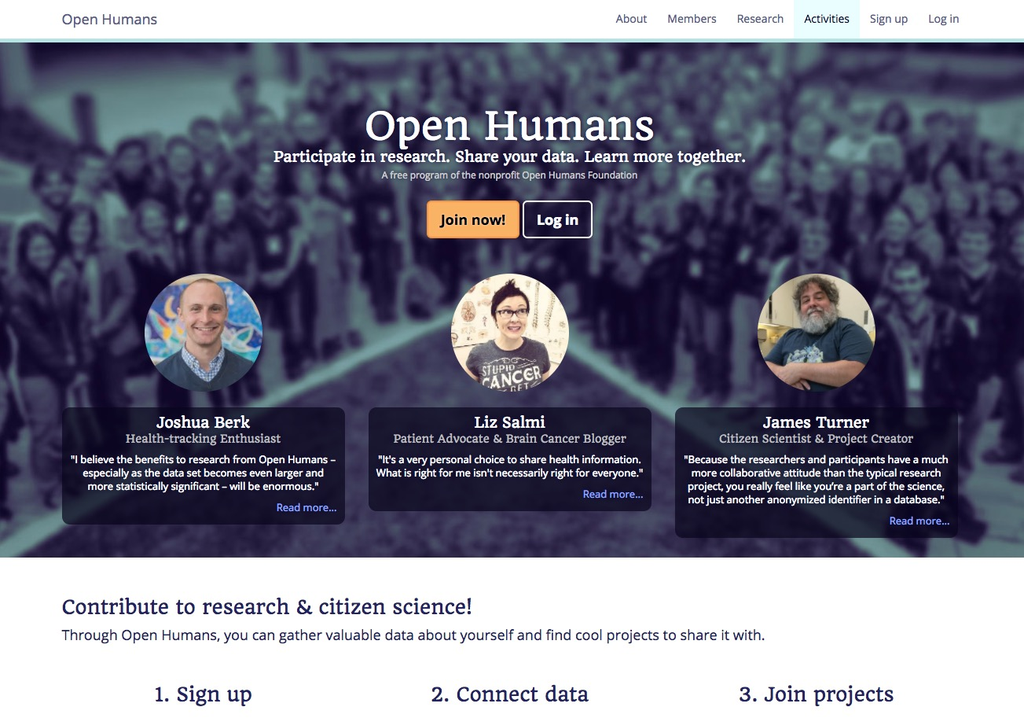

## Enable web-based data visualization, analysis

[video not shown]

[figure not shown]

[video not shown]

## Support search, filtering by personal characteristics

[figure not shown]

## Encourage self/active curation of data, materials

[figure not shown]

## Provide consistent, clear sharing permissions structure

[figure not shown]

## Progress

| Example | Multi-measure | Indiv link/search | Visualize | Self-curate | Permissions |
| --- | --- | --- | --- | --- | --- |
| Databrary | ✔ | ✔ | tabular | ✔ | ✔ |
| Human Proj | ✔ | ✔ | ? | ? | ✔ |
| ICPSR | ✔ | ? | ✔ | ? | ✔ |
| Neurosynth | fMRI BOLD | group data | ✔ | public | NA |
| OpenNeuro | ✔ | ? | ✔ | ✔ | public |
| Open Humans | ✔ | ✔ | ? | ? | ✔ |
| OSF | ✔ |  |  | ✔ | public |
| WordBank | M-CDI | group metadata | ✔ | ? | public |

## Barriers

[figure not shown]

## Humans are diverse

- But much (lab-based) data collected are from **W**estern, **E**ducated **I**ndustrialized, **R**ich, **D**emocratic (WEIRD) populations [Henrich et al., 2010](http://doi.org/10.1017/S0140525X0999152X)

[figure not shown]

http://www.evoanth.net/2015/01/06/evolutionary-psychology-has-problems-and-it-isnt-getting-better/

[figure not shown]

[figure not shown]

[(LeWinn, Sheridan, Keyes, Hamilton, & McLaughlin, 2017)](http://doi.org/10.1038/s41467-017-00908-7)

## Data sensitive, hard(er) to share

- Protect participant's identities
- Protect from harm/embarrassment
- Anonymize (effective?) or get permission (many don't ask, plan to share)

[figure not shown]

> *"…psychologists tend to treat other peoples’ theories like toothbrushes; no self-respecting individual wants to use anyone else’s."*

[Walter Mischel, 2009](https://www.psychologicalscience.org/observer/becoming-a-cumulative-science)

> *"Reviewers and editors want novel, interesting results. Why would I waste my time doing careful direct replications?"*

Any number of researchers I've talked with

[figure not shown]

([Munafo et al., 2017](http://doi.org/10.1038/s41562-016-0021))

[figure not shown]

## Let's build a Databservatory for human behavior

[figure not shown]

## It should…

- Store & share data & materials
- Link data across studies, measures
- Link across group characteristics, individuals
- Enable searching & filtering by individual characteristics, tasks, settings
- Support web-based data analysis, visualization; open API
- Provide consistent framework for ethical data sharing
- Enable data aggregation, cloning, provenance tracking
- Support self/active curation
- Link to publications &…

## Let us embrace [the whole elephant](http://gilmore-lab.github.io/2017-10-18-the-whole-elephant)

[figure not shown]

## References

Adamiak, W., Thomas, A., Patel, S., & Gilmore, R. (2015). Adult Observer’s Sensitivity to Optic Flow Varies by Pattern and Speed. *Journal of Vision*, *15*(12), 1008. https://doi.org/10.1167/15.12.1008

Gilmore, R. O., & Adolph, K. E. (2017). Video can make behavioural science more reproducible. *Nature Human Behavior*, *1*. https://doi.org/10.1038/s41562-017-0128

Gilmore, R. O., Raudies, F., & Jayaraman, S. (2015). What accounts for developmental shifts in optic flow sensitivity? In *2015 Joint IEEE International Conference on Development and Learning and Epigenetic Robotics (ICDL-EpiRob)* (pp. 19–25). https://doi.org/10.1109/DEVLRN.2015.7345450

Gilmore, R., Hou, C., Pettet, M., & Norcia, A. (2007). Development of cortical responses to optic flow. *Visual Neuroscience*, *24*(06), 845–856. https://doi.org/10.1017/S0952523807070769

Gilmore, R., Thomas, A., & Fesi, J. (2016). Children’s Brain Responses to Optic Flow Vary by Pattern Type and Motion Speed. *PLOS ONE*, *11*(6), e0157911. https://doi.org/10.1371/journal.pone.0157911

Hou, C., Gilmore, R., Pettet, M., & Norcia, A. (2009). Spatio-temporal tuning of coherent motion evoked responses in 4–6 month old infants and adults. *Vision Research*, *49*(20), 2509–2517. https://doi.org/10.1016/j.visres.2009.08.007

Jouen, F., Lepecq, J.-C., Gapenne, O., & Bertenthal, B. I. (2000). Optic flow sensitivity in neonates. *Infant Behavior and Development*, *23*(3–4), 271–284. https://doi.org/10.1016/S0163-6383(01)00044-3

Kiorpes, L., & Movshon, J. A. (2004). Development of sensitivity to visual motion in macaque monkeys. *Visual Neuroscience*, *21*(6), 851–859. https://doi.org/10.1017/S0952523804216054

LeWinn, K. Z., Sheridan, M. A., Keyes, K. M., Hamilton, A., & McLaughlin, K. A. (2017). Sample composition alters associations between age and brain structure. *Nat. Commun.*, *8*(1), 874. https://doi.org/10.1038/s41467-017-00908-7

Raudies, F., & Gilmore, R. (2014). Visual Motion Priors Differ for Infants and Mothers. *Neural Computation*, *26*(11), 2652–2668. https://doi.org/10.1162/NECO_a_00645

Yu, C. P., Page, W. K., Gaborski, R., & Duffy, C. J. (2010). Receptive Field Dynamics Underlying MST Neuronal Optic Flow Selectivity. *Journal of Neurophysiology*, *103*(5), 2794–2807. https://doi.org/10.1152/jn.01085.2009